# Forecasting of Inbound Tourist Demand in Thailand: Assessing Recurrent Neural Networks

### 4.3 Handling Outliers

Outliers in the residuals are identified as values exceeding three interquartile ranges (IQRs) beyond the central 50% of the data (Hyndman & Athanasopoulos, 2021). However, not all identified outliers are linked to COVID-19; some, particularly those before January 2020, reflect genuine increases in tourism demand.

```python
#--------------------

# Detect outliers

#--------------------

# Define helper function to detect outliers
def detect_outliers(data, threshold=3):
    """
    Detects outliers using the IQR method.

    Parameters:
    - data (array-like): Input numerical series.
    - threshold (float): Multiplier for IQR to define outliers (default is 3).

    Returns:
    - outliers (array-like): Boolean mask indicating outliers.
    - outlier_values (array-like): The actual outlier values.
    """
    Q1 = np.percentile(data, 25)
    Q3 = np.percentile(data, 75)
    IQR = Q3 - Q1

    # Define the outliers
    outliers = (data < (Q1 - threshold * IQR)) | (data > (Q3 + threshold * IQR))

    # Extract the outlier values
    outlier_values = data[outliers]

    return outliers, outlier_values

# Example usage:
outliers, outlier_values = detect_outliers(residuals)
print(outlier_values)
```

```
0
2019-08-01     969.433270
2019-11-01    1566.622327
2019-12-01    2134.935711
2020-01-01    2146.522450
2020-04-01   -1412.124588
2020-05-01   -1147.888111
Name: resid, dtype: float64
```

This complicates the decision on handling these outliers, leading to a preference for retaining them as they are. As shown in Figure 1, the COVID-19 pandemic introduced a shock to the tourism industry, causing significant shifts in travel patterns (UNWTO, 2020). The impact of this disruption is reflected in the subsequent observations. Given these complexities, determining an optimal approach to managing these outliers is left for future research, while acknowledging their potential impact on forecasting performance. This approach also allows me to assess the robustness of the selected NNs in adapting to such irregularities.

### 4.4 Moving Window Strategy

The Moving Window (MW) approach restructures a time series $X_i$ into multiple $\langle \text{input}, \text{output} \rangle$ segments, which are subsequently used for training recurrent neural network (RNN) models. Given a time series $X_i = \{x_1, \dots, x_l\} \in \mathbb{R}^l$ of length $l$, this method generates $(l - m - n)$ overlapping segments, where each segment consists of $(m + n)$ consecutive values. In this formulation, $m$ represents the input window size, and $n$ defines the forecast horizon (output window size), following the Multi-Input Multi-Output (MIMO) forecasting strategy (Bontempi, 2008; Bontempi & Taieb, 2011; Kline, 2004), which is widely adopted in the literature. Unlike recursive strategies that predict future values step by step, MIMO forecasts all future steps in a single iteration. This approach reduces error propagation (Wen et al., 2017) and better captures temporal dependencies between future values, rather than treating each step independently (Taieb et al., 2012). The input window size $m$ is determined following the methodology of Hewamalage et al. (2021) and Bandara et al. (Bandara et al., 2020), setting it proportional to the seasonality period. Specifically, for monthly data where the seasonality period is `12`, $m$ is defined by Equation 2 as:

$$m = 1.25 \times \text{seasonalityperiod}
\tag{2}$$

The coefficient `1.25` is chosen heuristically to ensure that the recurrent cells are exposed to at least one full seasonal cycle, enabling the model to capture any remaining stochastic seasonality. Additionally, trend normalization is applied as described in Section 4.2.

```python
#--------------------

# Create Moving Window (MW) patches with local trend normalization

#--------------------

# Deifne helper function for MIMO patches
def create_mw_mimo_patches(sequence, trend, m, n):
    """
    Creates Moving Window (MW) patches for Multiple Input Multiple Output (MIMO)
    forecasting with local trend normalization.

    Parameters:
    - sequence (array-like): Deseasonalized series (after STL decomposition).
    - trend (array-like): Trend component of the time series from STL decomposition.
    - m (int): Input window size.
    - n (int): Output window size (forecast horizon).

    Returns:
    - X_train (numpy array): Input windows for training (shape: (samples_train, m)).
    - Y_train (numpy array): Output windows for training (shape: (samples_train, n)).
    - X_val (numpy array): Input windows for validation (shape: (samples_val, m)).
    - Y_val (numpy array): Output windows for validation (shape: (samples_val, n)).
    """

    l = len(sequence)  # Total length of sequence

    # The last 'n' points are left out for validation
    validation_start = l - (m + n)  # Start of validation
    training_end = validation_start - n  # End of training

    X_train, Y_train = [], []
    X_val, Y_val = [], []

    # Training samples: from start to training_end, ensuring valid (m+n) window
    for i in range(training_end - m - n):
        # Extract input and output windows
        x_window = sequence[i:i + m]
        y_window = sequence[i + m:i + m + n]

        # Get the trend value at the last time step of the input window
        trend_value = trend.iloc[i + m - 1]

        # Apply per-window trend normalization
        X_train.append(x_window - trend_value)
        Y_train.append(y_window - trend_value)

    # Validation samples: from validation_start to
    # validation_end, ensuring valid (m+n) window
    for i in range(validation_start - m - n, validation_start - n):
        x_window = sequence[i:i + m]
        y_window = sequence[i + m:i + m + n]

        # Get the trend value at the last time step of the input window
        trend_value = trend.iloc[i + m - 1]

        # Apply per-window trend normalization
        X_val.append(x_window - trend_value)
        Y_val.append(y_window - trend_value)

    # Convert to NumPy arrays
    return np.array(X_train), np.array(Y_train), np.array(X_val), np.array(Y_val)


# Define window sizes
seasonality_period = 12
# m defined based on Hewamalage et al. (2021) and Bandara et al. (2020)
m = int(1.25 * seasonality_period)
n = 3  # Forecasting horizon

# Apply trend normalization within moving windows
X_train, y_train, X_val, y_val = create_mw_mimo_patches(deseasonalized_train_series,
                                                        trend, m, n)

# Print sizes for verification
print(f"Training samples: {X_train.shape}, {y_train.shape}")
print(f"Validation samples: {X_val.shape}, {y_val.shape}")
```

```
Training samples: (74, 15), (74, 3)
Validation samples: (15, 15), (15, 3)
```

```python
# Add feature dimension to X_train and X_val after patch creation
X_train = X_train.reshape((X_train.shape[0], 1, X_train.shape[1]))
X_val = X_val.reshape((X_val.shape[0], 1, X_val.shape[1]))
```

## 5 Methodology and Experiment

This research explores different recurrent units, architectures, learning frameworks and hyperparameter optimization techniques. Additionally, benchmark models are defined and trained for later evaluation, allowing for a comparison of their performance with the RNN models. All NN models are implemented using Keras (Chollet, 2015) and TensorFlow (Abadi et al., 2015), with experiments conducted on a local Mac M1 system.

### 5.1 Recurrent Neural Networks

RNN are widely used in time series forecasting for their ability to model sequential dependencies. They maintain an internal memory state that updates at each time step, enabling the capture of temporal patterns and trends (Lim & Zohren, 2021). The following sections present most common RNN variants used in this work.

#### 5.1.1 Recurrent Units

The core building blocks of RNN are recurrent units, which can generally be categorized into three main classes.

##### 5.1.1.1 Elman Recurrent Unit (ERNN)

The Elman Recurrent Neural Network (ERNN), introduced by Elman (1990), is a foundational recurrent unit for processing sequential data. It maintains a hidden state that updates recursively based on the previous hidden state and the current input. The ERNN is governed by the following Equation 3:

$$\begin{aligned}
h_t = \sigma(W_i \cdot h_{t-1} + V_i \cdot x_t + b_i)
z_t = \tanh(W_o \cdot h_t + b_o)
\end{aligned}
\tag{3}$$

Where:

- $h_t \in \mathbb{R}^d$ is the hidden state.
- $x_t \in \mathbb{R}^m$ is the input at time step $t$.
- $W_i, V_i \in \mathbb{R}^{d \times d}$ and $W_o \in \mathbb{R}^{d \times d}$ are weight matrices.
- $b_i$ and $b_o$ are bias terms.

In this model, the hidden state activation function is the sigmoid function, and the output activation function is the hyperbolic tangent function. ERNN struggles with long sequences due to vanishing and exploding gradient issues, limiting their ability to capture long-term dependencies. While this poses challenges for long-term forecasting, it is less problematic for short-term predictions, such as those in this experiment. The ERNN cell is shown in Figure 4.

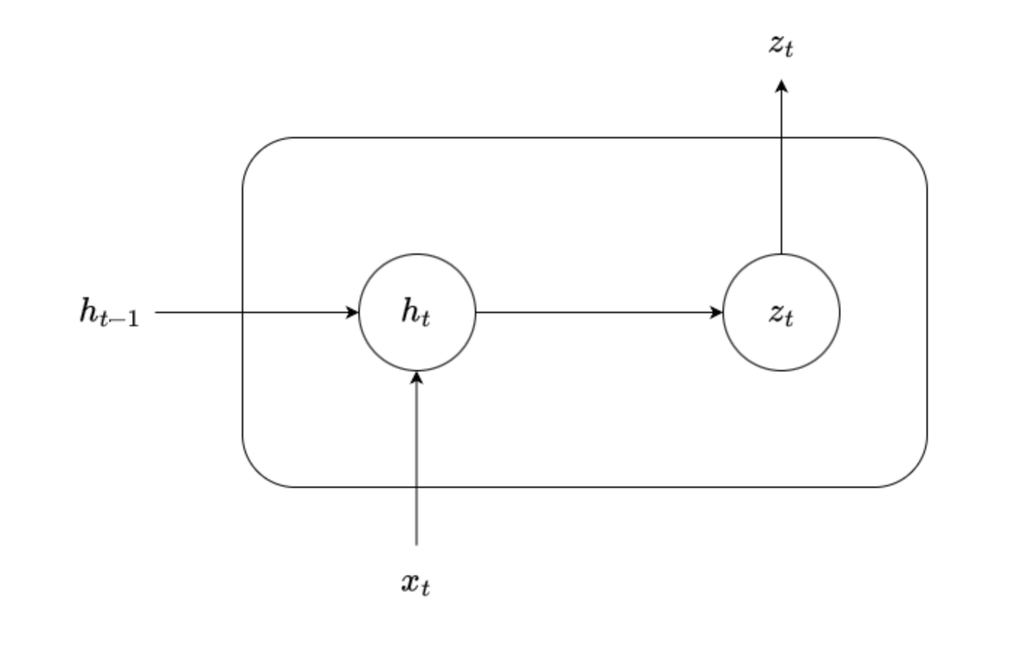

Figure 4: Elman Recurrent Unit

##### 5.1.1.2 Long Short-Term Memory (LSTM)

The LSTM (Hochreiter & Schmidhuber, 1997) helps with the vanishing gradient problem and includes memory cells as expressed by the following Equation 4:

$$\begin{aligned}
i_t &= \sigma(W_i \cdot h_{t-1} + V_i \cdot x_t + b_i) \\
f_t &= \sigma(W_f \cdot h_{t-1} + V_f \cdot x_t + b_f) \\
\tilde{C}_t &= \tanh(W_c \cdot h_{t-1} + V_c \cdot x_t + b_c) \\
C_t &= f_t \cdot C_{t-1} + i_t \cdot \tilde{C}_t \\
o_t &= \sigma(W_o \cdot h_{t-1} + V_o \cdot x_t + b_o) \\
h_t &= o_t \cdot \tanh(C_t)
\end{aligned}
\tag{4}$$

Where:

- $C_t$ is the cell state (memory).
- $i_t, f_t, o_t$ are the input, forget, and output gates.
- $\tilde{C}_t$ is the candidate cell state.
- $h_t$ is the hidden state.

The activation functions used are the sigmoid function for the gates and the hyperbolic tangent function for the candidate cell state and the output. The cell state $C_t$ retains long-term information, which is controlled and updated by a series of gates. Figure 5 shows the LSTM cell.

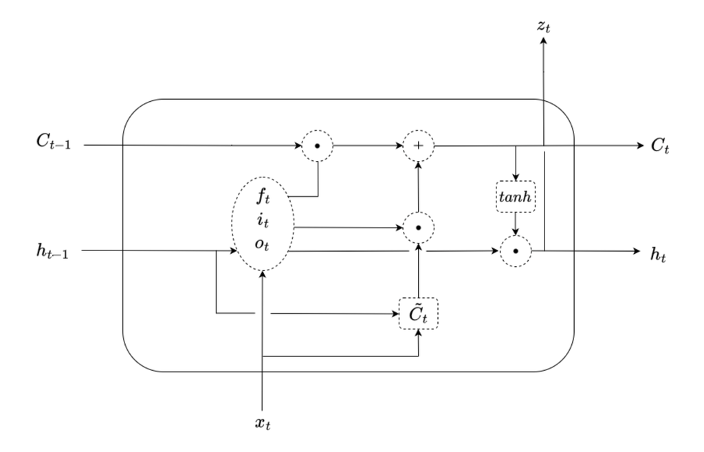

Figure 5: Basic LSTM Cell Unit

##### 5.1.1.3 Gated Recurrent Unit (GRU)

The GRU (Cho et al., 2014) simplifies the LSTM architecture with two gates, the update gate ($u_t$) and the reset gate ($r_t$) as the following Equation 5 shows:

$$\begin{aligned}
u_t = \sigma(W_u \cdot h_{t-1} + V_u \cdot x_t + b_u) \\
r_t = \sigma(W_r \cdot h_{t-1} + V_r \cdot x_t + b_r) \\
\tilde{h}_t = \tanh(W_h \cdot (r_t \cdot h_{t-1}) + V_h \cdot x_t + b_h) \\
h_t = u_t \cdot \tilde{h}_t + (1 - u_t) \cdot h_{t-1}
\end{aligned}
\tag{5}$$

The update gate combines the roles of both the forget and input gates, while the reset gate controls how much of the previous hidden state contributes to the current candidate state. The GRU is more efficient than LSTM due to fewer parameters and simpler computations, making it faster to train. Figure 6 Shows the GRU cell.

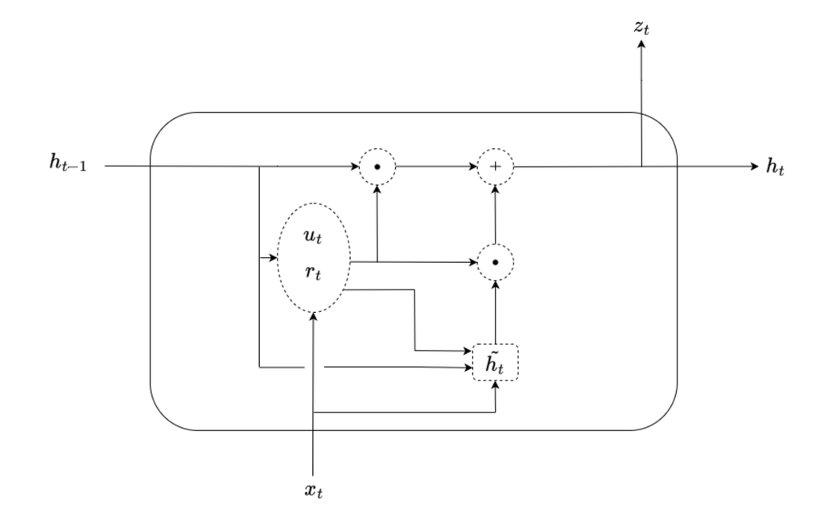

Figure 6: GRU Unit

#### 5.1.2 Recurrent Architecture

The recurrent architecture defines how recurrent units process sequential data. Two main types of architectures are typically used: stacked and Sequence-to-Sequence (S2S) architectures. In this study, the stacked architecture from Bandara et al. (2020) is used, where the same RNN unit is applied at each time step with shared weights and biases. The state $h_t$ is passed to the next time step through the feedback loop. For LSTM cells, the cell state $C_t$ is also involved. Figure 7 shows the basic setup with a single RNN layer. In a multi-layer setup, multiple RNN layers are stacked on top of each other, with the output from each layer serving as input to the next, ultimately generating the final forecasts $\hat{Y}_t$ from the last layer. The input at each time step is preprocessed using the moving window strategy, and a dense layer projects the output to the expected forecasting horizon. During training, the error at each time step $e_t = Y_t - \hat{Y}_t$ is accumulated across all time steps to compute the total error $E = \sum_{t=1}^{T} e_t$. This accumulated error is then used in Backpropagation Through Time (BPTT) to update the RNN’s weights and biases.

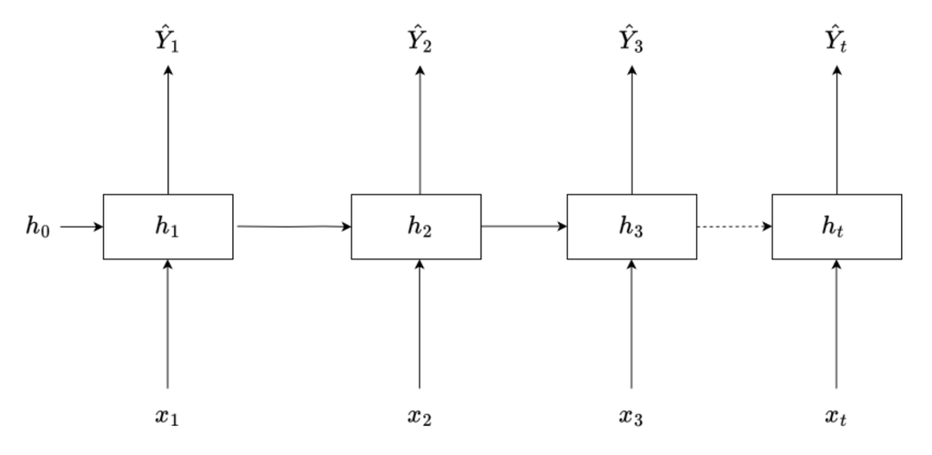

Figure 7: Stacked Architecture

#### 5.1.3 Learning algorithms

Here, I test two widely used optimizers: Adam (Kingma & Ba, 2015) and Adagrad (Duchi et al., 2011). Adagrad uses adaptive learning rates by assigning a separate rate to each parameter, allowing independent weight updates. However, its learning rate decreases over time due to accumulating squared gradients, which can slow convergence. Adam builds on Adagrad by incorporating exponentially decaying averages of past gradients and squared gradients, preventing vanishing learning rates. This makes Adam more robust and generally more effective in training deep learning models.

#### 5.1.4 Hyperparameter Tuning

The hyperparameters considered are:

1. **Minibatch size**: the number of time series used for each training step.
2. **Number of epochs**: the total number of times the model cycles through the entire dataset.
3. **Epoch size**: defines how many times the dataset is traversed within each epoch.
4. **Learning rate**: controls the adjustments the model makes in response to the estimated error, using Adam and Adagrad optimizers.
5. **Gaussian noise standard deviation**: determines the scale of zero-mean Gaussian noise added to inputs during training, serving as a data augmentation technique to help maintain model accuracy in the presence of drift (Fields et al., 2019), as observed in disruptions to travel patterns caused by COVID-19.
6. **L2 regularization parameter**: a penalty term that discourages large weights to avoid overfitting. L2 regularization is selected due to its proven effectiveness in previous studies cited in this work while also mitigating potential vanishing gradient problems (Pascanu et al., 2013).
7. **RNN cell dimension**: defines the number of hidden units per RNN cell, affecting the model’s complexity and ability to capture sequence patterns.
8. **Number of hidden layers**: sets the depth of the neural network, with a maximum of two layers to prevent overfitting when working with limited observations while minimizing complexity.
9. **Random normal initializer standard deviation**: influences the standard deviation of random weight initializations, impacting model convergence, and is chosen due to its widespread use in the literature (Glorot & Bengio, 2010; Mehdipour Ghazi et al., 2019).

These hyperparameters are tuned using a Bayesian global optimization approach (Snoek et al., 2012), which employs Bayesian inference in combination with a Gaussian process. This technique enables autonomous optimization of hyperparameters by leveraging a validation set. The choice of Bayesian optimization, instead of methods like grid search, is due to the fact that grid search can be computationally expensive and time-consuming, especially when running locally. Specifically, I utilize the `BayesianOptimization` function from the `bayesian-optimization` package (Fernando, 2017) for this purpose. The ranges for the hyperparameters are selected based on the ones used for the tourism dataset in Hewamalage et al. (2021), which are summarized in Table 1.

Table 1: Hyperparameters and their range

[output not shown]

Lastly, input and output window sizes are chosen throughout the experiments based on the considerations discussed in Section 4.4.

#### 5.1.5 Training and Validation

The RNN models are trained and optimized using the Mean Absolute Error (MAE) loss function and Early Stopping is applied to ensures that each candidate model in the Bayesian Optimization process trains only as long as necessary, improving efficiency and further preventing overfitting (Goodfellow et al., 2016). The optimal hyperparameters identified during training are presented in Table 2, with simpler models being the preferred choice, as expected given the limited number of observations.

```python
# import Tensorflow and Keras modules (Abadi et al. 2015; Chollet 2015)
import tensorflow as tf
from tensorflow.keras.models import Sequential
from tensorflow.keras.layers import SimpleRNN, GRU, LSTM, Dense, GaussianNoise
from tensorflow.keras.optimizers import Adam, Adagrad
from tensorflow.keras.regularizers import l2
from tensorflow.keras.callbacks import EarlyStopping
import random
import math
import os

# Set a fixed seed value for reproducibility
seed_value = 42

# Set seed for Python's built-in random module
random.seed(seed_value)

# Set seed for NumPy
np.random.seed(seed_value)

# Set seed for TensorFlow
tf.random.set_seed(seed_value)

# Ensure reproducibility for TensorFlow
os.environ['PYTHONHASHSEED'] = str(seed_value)
os.environ['TF_DETERMINISTIC_OPS'] = '1'
```

```python
#--------------------

# Build the RNN model

#--------------------


# Define RNNModel Class
class RNNModel(tf.keras.Model):
    """
    A subclassed RNN model supporting SimpleRNN (ERNN), GRU, and LSTM.
    """

    def __init__(self, noise_std, model_layer, cell_dim, initializer_std,
                 l2_reg, num_layers, learning_rate, learning_algorithm, seed=None):
        """
        Initializes the RNN model.

        Parameters:
        -----------
        noise_std : float
            Standard deviation for Gaussian noise.
        model_layer : str
            Type of RNN layer ('ERNN', 'GRU', 'LSTM').
        cell_dim : int
            Number of units in each RNN layer.
        initializer_std : float
            Standard deviation for weight initialization.
        l2_reg : float
            L2 regularization factor.
        num_layers : int
            Number of RNN layers.
        learning_rate : float
            Learning rate for the optimizer.
        learning_algorithm : str
            Type of optimizer ('Adam' or 'Adagrad').
        seed : int, optional
            Random seed for reproducibility (default: None).
        """
        super().__init__()

        # Set seed
        self.seed = seed

        # Store attributes
        self.num_layers = num_layers
        self.learning_algorithm = learning_algorithm

        # Gaussian Noise Layer to add noise to the input sequence
        self.noise = GaussianNoise(noise_std)

        # Initialize RNN layer type based on user input
        rnn_layer = {
            'ERNN': SimpleRNN,
            'GRU': GRU,
            'LSTM': LSTM
        }.get(model_layer, None)

        if rnn_layer is None:
            raise ValueError("Invalid model_layer. Choose from 'ERNN', 'GRU', or 'LSTM'.")

        # Define RNN layers
        self.rnn_layers = [
            rnn_layer(
                cell_dim,
                activation='sigmoid',
                kernel_initializer=tf.keras.initializers.\
                RandomNormal(stddev=initializer_std, seed=self.seed),
                kernel_regularizer=l2(l2_reg),
                recurrent_initializer=tf.keras.initializers.\
                RandomNormal(stddev=initializer_std,  seed=self.seed),
                return_sequences=(i < num_layers - 1)  # Last layer only returns False
            ) for i in range(num_layers)
        ]

        # Dense output layer (3-step ahead forecast)
        self.dense = Dense(units=3, activation='tanh')

        # Set optimizer based on user input
        if self.learning_algorithm == 'Adam':
            self.optimizer = Adam(learning_rate=learning_rate)
        elif self.learning_algorithm == 'Adagrad':
            self.optimizer = Adagrad(learning_rate=learning_rate)
        else:
            raise ValueError("Invalid learning_algorithm. Choose 'Adam' or 'Adagrad'.")

        # Compile model with Mean Absolute Error (MAE) loss
        self.compile(optimizer=self.optimizer, loss='mae')

    def call(self, inputs, training=False):
        """
        Forward pass of the RNN.

        Parameters:
        -----------
        inputs : tf.Tensor
            Input tensor of shape (batch_size, timesteps, features).
        training : bool
            Whether the model is in training mode.

        Returns:
        --------
        tf.Tensor
            Output tensor of shape (batch_size, 3).
        """
        x = self.noise(inputs, training=training)  # Apply Gaussian noise
        for rnn_layer in self.rnn_layers:
            x = rnn_layer(x)  # Apply each RNN layer sequentially
        return self.dense(x)  # Final dense layer for 3-step ahead forecasting

    def train(self, X_train, y_train, batch_size, epochs, validation_data=None):
        """
        Trains the model using the provided dataset.

        Parameters:
        -----------
        X_train : np.array or tf.Tensor
            Training input data.
        y_train : np.array or tf.Tensor
            Training target data.
        batch_size : int
            Number of samples per batch.
        epochs : int
            Number of training epochs.
        validation_data : tuple, optional
            A tuple (X_val, y_val) for validation.

        Returns:
        --------
        history : keras.callbacks.History
            Training history containing loss and validation metrics.
        """

        # Set Early Stopping
        # Dynamically select the monitoring metric based on validation availability
        early_stopping = EarlyStopping(
            monitor="val_loss" if validation_data else "loss",
            patience=3,
            restore_best_weights=True
        )

        # Fit the model and get the history
        history = self.fit(
            X_train, y_train,
            batch_size=batch_size,
            epochs=epochs,
            validation_data=validation_data,
            verbose=0,
            callbacks=[early_stopping]
        )

        # Return the complete history object
        return history
```

```python
#--------------------

#  Build the optimization function

#--------------------


# Import BayesianOptimization method (Fernando 2017)
from bayes_opt import BayesianOptimization

# Define the optimize_rnn function
def optimize_rnn(model_layer, learning_algorithm, pbounds, X_train, y_train,
                 X_val, y_val, seed=None):
    """
    Runs Bayesian Optimization for a specific optimizer type.

    Args:
        model_layer (str): The type of RNN layer (e.g., 'ERNN', 'GRU', 'LSTM').
        learning_algorithm (str): The optimizer to use (e.g., 'Adam', 'Adagrad').
        pbounds (dict): Dictionary specifying the range of hyperparameters.
        X_train (np.array): Training feature set.
        y_train (np.array): Training labels.
        X_val (np.array): Validation feature set.
        y_val (np.array): Validation labels.

    Returns:
        dict: Best hyperparameters found, including the selected optimizer.
    """

    # Define optimizer-specific learning rate bounds
    learning_rate_bounds = {
        'Adam': (0.001, 0.1),
        'Adagrad': (0.01, 0.9)
    }

    if learning_algorithm not in learning_rate_bounds:
        raise ValueError(f"Unknown learning algorithm: {learning_algorithm}")

    # Update pbounds with the correct learning rate range
    pbounds['learning_rate'] = learning_rate_bounds[learning_algorithm]

    # Define the objective function for Bayesian Optimization
    def rnn_val_loss(batch_size, epochs, learning_rate, noise_std, l2_reg,
                     cell_dim, num_layers, initializer_std, seed=None):
        """
        Objective function for Bayesian Optimization.

        Args:
            batch_size (float): Batch size for training.
            epochs (float): Number of training epochs.
            learning_rate (float): Learning rate for optimization.
            noise_std (float): Standard deviation for noise regularization.
            l2_reg (float): L2 regularization factor.
            cell_dim (float): Number of units per RNN cell.
            num_layers (float): Number of RNN layers.
            initializer_std (float): Standard deviation for weight initialization.

        Returns:
            float: Minimum validation loss achieved during training.
        """
        rnn_model = RNNModel(
            model_layer=model_layer,
            cell_dim=int(cell_dim),
            num_layers=int(num_layers),
            l2_reg=l2_reg,
            learning_rate=learning_rate,
            learning_algorithm=learning_algorithm,
            noise_std=noise_std,
            initializer_std=initializer_std,
            seed=seed
        )

        # initialize and train the model
        rnn_model(X_train[:1])
        history = rnn_model.train(X_train, y_train, batch_size=int(batch_size),
                                  epochs=int(epochs), validation_data=(X_val, y_val))

        return min(history.history['val_loss'])  # Return the lowest validation loss

    # Initialize Bayesian Optimization
    optimizer = BayesianOptimization(
        f=rnn_val_loss,
        pbounds=pbounds,
        random_state=42,
        verbose=0
    )

    optimizer.maximize(init_points=5, n_iter=10)

    # Store the best result
    best_result = optimizer.max
    best_result['params']['learning_algorithm'] = learning_algorithm

    return best_result  # Return the best hyperparameters found
```

```python
#--------------------

#  Step 1: Train the models and optimize hyperparameters using Bayesian Optimization

#--------------------

# Define hyperparameter bounds
pbounds = {
    'batch_size': (10, 90),
    'epochs': (3, 100),
    'learning_rate': None,  # Dynamically updated based on optimizer
    'noise_std': (0.0001, 0.0008),
    'l2_reg':   (0.0001, 0.0008),
    'cell_dim': (20, 25),
    'num_layers': (1, 2),
    'initializer_std': (0.0001, 0.0008)
}

# List of RNN layers to optimize over
model_layers = ['ERNN', 'GRU', 'LSTM']
# List of learning algorithms
learning_algorithms = ['Adam', 'Adagrad']

# Dictionary to store the best hyperparameters for each model layer
best_hyperparameters = {}

# Hyperparameters that should be stored as integers
int_columns = ['batch_size', 'cell_dim', 'epochs', 'num_layers']

# Optimize for each model layer and select the best optimizer
for model_layer in model_layers:
    best_result = None  # Track the best optimization result for this model layer
    best_optimizer = None  # Track the best optimizer

    # Iterate over each learning algorithm
    for learning_algorithm in learning_algorithms:
        print(f"\nOptimizing for {model_layer} with {learning_algorithm} optimizer...")
        result = optimize_rnn(
            model_layer, learning_algorithm, pbounds, X_train,
            y_train, X_val, y_val, seed=seed_value
        )

        # Select the optimizer with the lowest validation loss
        if best_result is None or result['target'] < best_result['target']:
            best_result = result
            best_optimizer = learning_algorithm

    # Convert specified hyperparameters to integers before storing
    for col in int_columns:
        if col in best_result['params']:
            best_result['params'][col] = math.floor(best_result['params'][col])

    # Store only the best optimizer's results for the model layer
    best_hyperparameters[model_layer] = best_result
    print(
    f"Best optimizer for {model_layer}: {best_optimizer} "
    f"with loss {best_result['target']:.4f}"
    )
```

Table 2: Optimal hyperparameters and target loss for each model layer, obtained through Bayesian Optimization

| Model Layer | Target Loss | Batch Size | Cell Dim | Epochs | Initializer Std | L2 Reg | Learning Rate | Noise Std | Num Layers | Learning Algorithm |
| --- | --- | --- | --- | --- | --- | --- | --- | --- | --- | --- |
| ERNN | 1879.632568 | 14 | 22 | 3 | 0.000107 | 0.000493 | 0.096174 | 0.000740 | 1 | Adam |
| GRU | 1879.634888 | 46 | 23 | 22 | 0.000460 | 0.000515 | 0.005599 | 0.000525 | 1 | Adam |
| LSTM | 1879.645996 | 89 | 20 | 26 | 0.000167 | 0.000500 | 0.083629 | 0.000257 | 1 | Adam |

#### 5.1.6 Testing and Forecasts Generation

Once the optimal hyperparameters are identified, the models are retrained using the complete training dataset. Forecasts are then generated and undergo the following post-processing steps:

- Reversal of local normalization: the local normalization is reversed by adding the trend value of the last input point.
- Reversal of deseasonalization: the seasonality components are added back to the forecasted values.

Finally, the forecasts are readied for evaluation against both the test set and the benchmarks.

```python
#--------------------

#  Define the function to retrain the models

#--------------------

def retrain_model(model_layer, hyperparams, X_full_train, y_full_train):
    """
    Retrains an RNN model with the given hyperparameters and training data.

    Args:
        model_layer (str): Type of the model layer (e.g., 'LSTM', 'GRU').
        hyperparams (dict): A dictionary containing the hyperparameters for the model.
                            Expected keys include:
                            - 'noise_std': Standard deviation for noise regularization.
                            - 'cell_dim': Number of units per RNN cell.
                            - 'initializer_std': Std. for weight initialization.
                            - 'l2_reg': L2 regularization factor.
                            - 'num_layers': Number of RNN layers.
                            - 'learning_rate': Learning rate for the optimizer.
                            - 'learning_algorithm': Optimization algorithm.
                            - 'batch_size': Batch size for training.
                            - 'epochs': Number of epochs for training.
        X_full_train (numpy.ndarray): The training features.
        y_full_train (numpy.ndarray): The target variable corresponding to the training data.

    Returns:
        RNNModel: The trained RNN model instance.
    """
    # Unpack hyperparameters
    noise_std = hyperparams['noise_std']
    cell_dim = hyperparams['cell_dim']
    initializer_std = hyperparams['initializer_std']
    l2_reg = hyperparams['l2_reg']
    num_layers = hyperparams['num_layers']
    learning_rate = hyperparams['learning_rate']
    learning_algorithm = hyperparams['learning_algorithm']

    # Create an RNNModel instance for the given model layer type
    rnn_model = RNNModel(
        noise_std=noise_std,
        model_layer=model_layer,
        cell_dim=cell_dim,
        initializer_std=initializer_std,
        l2_reg=l2_reg,
        num_layers=num_layers,
        learning_rate=learning_rate,
        learning_algorithm=learning_algorithm
    )

    # Define the input shape for the model (timesteps, features)
    input_shape = (X_full_train.shape[1], X_full_train.shape[2])

    # Initialize the model
    rnn_model(X_full_train[:1])

    # Train the model (using the last part of training data, no need for validation here)
    history = rnn_model.train(X_full_train, y_full_train,
                              hyperparams['batch_size'],
                              epochs=hyperparams['epochs'])
    # Return RNN model
    return rnn_model
```

```python
#--------------------

# Define the function to generate forecasts

#--------------------

def generate_forecast(rnn_model, X_full_train, m):
    """
    Generates a forecast for the next 'm' time steps based on the trained RNN model.

    Args:
        rnn_model (RNNModel): The trained RNN model instance used to generate the forecast.
        X_full_train (numpy.ndarray): The training features.
        m (int): The number of forecast steps ahead.

    Returns:
        numpy.ndarray: The forecasted values for the next 'm' time steps.
    """
    # Get the last input sequence from the training data
    last_input = X_full_train[-1].reshape((1, X_full_train.shape[1], X_full_train.shape[2]))

    # Generate a forecast for the next forecast_steps
    forecast = rnn_model.predict(last_input, verbose=0)

    # Return the forecast
    return forecast
```

```python
#--------------------

# Define the function to extend seasonal pattern

#--------------------

def extend_seasonality(seasonal, steps):
    """
    Extend the seasonal component by repeating it cyclically.

    Parameters:
    - seasonal (Pandas Series): The seasonal component from STL decomposition.
    - steps (int): Number of future steps to extend.

    Returns:
    - extended_seasonal (numpy array): Extended seasonal values.
    """
    # Get cycle length
    cycle_length = len(seasonal)
    # Extend seasonality
    extended_seasonal = np.tile(seasonal.values, steps // cycle_length + 1)[:steps]

    # Return extended seasonality
    return extended_seasonal
```

```python
#--------------------

#  Step 3: Retrain the models and generate forecasts

#--------------------

# Get the entire training set (X_train + X_val)
X_full_train = np.concatenate((X_train, X_val), axis=0)
y_full_train = np.concatenate((y_train, y_val), axis=0)

# Dictionary to store the final trained models and forecasts
trained_models = {}
forecasts = {}

# Iterate over each model layer type
for model_layer in model_layers:
    # Get the best hyperparameters for the current model layer
    hyperparams = best_hyperparameters[model_layer]['params']

    # Retrain the model with the best hyperparameters
    trained_model = retrain_model(model_layer, hyperparams, X_full_train, y_full_train)

    # Generate a forecast using the trained model
    forecast = generate_forecast(trained_model, X_full_train, m)

    # Store the trained model and forecast
    trained_models[model_layer] = trained_model
    forecasts[model_layer] = forecast
```

```python
#--------------------

#  Step 4:  Reverse forecasts to original values

#--------------------

# Ensure test_dates is properly formatted
test_dates = pd.to_datetime(['2024-06-01', '2024-07-01', '2024-08-01'])

# Dictionary to store reverted forecasts for each model layer
reverted_forecasts = {}

# Iterate over each model layer and revert its forecast
for model_layer in forecasts:
    forecast_values = forecasts[model_layer]

    # Extend seasonal component
    seasonal_values = extend_seasonality(seasonal, 3)

    # Use the last trend value to adjust normalization
    trend_values =  np.full_like(forecast_values, trend.iloc[-1])

    # Revert normalization and deseasonalization
    reverted_values = (forecast_values + seasonal_values  + trend_values).flatten()

    # Convert to Pandas Series with corresponding test dates
    reverted_forecasts[model_layer] = pd.Series(reverted_values, index=test_dates)
```

```python
# Convert reverted_forecasts dictionary to a DataFrame
rnn_forecasts_df = pd.DataFrame(reverted_forecasts)

# Reset index and rename it to 'ds' for later comparison
rnn_forecasts_df = rnn_forecasts_df.reset_index().rename(columns={'index': 'ds'})

# Ensure 'ds' is in datetime format
rnn_forecasts_df['ds'] = pd.to_datetime(rnn_forecasts_df['ds'])
```

### 5.2 Benchmark Models for Comparison

To assess the effectiveness of RNN in forecasting inbound tourists to Thailand, it’s important to compare their performance against benchmark models. Benchmarks provide a baseline, ensuring that more complex models offer true improvements in prediction accuracy. Simpler models are often easier to interpret, less computationally demanding and more reliable in practical, real-world scenarios. More sophisticated models, such as RNN, should only be considered if they demonstrate a clear advantage over these simpler alternatives. To ensure a well-rounded approach to model selection, the following traditional forecasting models, implemented using the `StatsForecast` library (Garza et al., 2022), have been selected for comparison due to their popularity and established effectiveness in forecasting. These benchmarks will help assess whether RNN offers substantial improvements in forecasting accuracy, justifying their use in practical applications. The models are applied to the training dataset without any preprocessing:

- Historic Average (`HistoricAverage`): a basic model that calculates the average of past observations.
- Seasonal Naïve (`SeasonalNaive`): assumes future values will replicate the most recent observation from the same season in the previous cycle.
- Random Walk With Drift (`RandomWalkWithDrift`): enhances the random walk model by incorporating a drift term, representing the average change in the historical data.
- Automatic ARIMA (`AutoARIMA`): a forecasting method that automatically selects the optimal ARIMA parameters for a dataset, optimizing model selection.
- Automatic ETS (`AutoETS`): utilizes Exponential Smoothing to model various components of time series data, such as trend and seasonality, and automatically selects the best configuration using an information criterion.

```python
# Import StatsForecasy Library and models (Garza et al. 2022)
from statsforecast import StatsForecast
from statsforecast.models import  HistoricAverage, SeasonalNaive, RandomWalkWithDrift
from statsforecast.models import  RandomWalkWithDrift, AutoARIMA, AutoETS

# this makes it so that the outputs of the predict methods have the id as a column
# instead of as the index
os.environ['NIXTLA_ID_AS_COL'] = '1'
```

```python
# Reset index and rename columns as required by StatsForecast
train_set_df = train_set.reset_index()
train_set_df.columns = ['ds', 'y']

# Add unique_id column with a constant value since it's a single series
train_set_df['unique_id'] = 1
```

```python
# Create a list of models and instantiation parameters
models = [
    HistoricAverage(),
    AutoARIMA(season_length=12),
    SeasonalNaive(season_length=12),
    RandomWalkWithDrift(),
    AutoETS()
]
```

```python
# Instantiate StatsForecast class as sf
sf = StatsForecast(
    models=models,
    freq='MS',
    fallback_model = SeasonalNaive(season_length=12),
    n_jobs=-1
)
```

```python
# fit the models
models_fitted = sf.fit(df=train_set_df)
```

```python
# Generate the forecasts
traditional_forecasts_df = models_fitted.predict(h=3, level=None)
```

## 6 Evaluation

When evaluating model performance, no single metric can be universally deemed the “best”. The appropriate metric depends on factors like data characteristics and the specific forecasting problem at hand (Hyndman & Koehler, 2006; Makridakis, 1993). Commonly used metrics, including Mean Absolute Error (MAE), Mean Absolute Percentage Error (MAPE), Root Mean Squared Error (RMSE) and those frequently used in forecasting competitions, such as Mean Absolute Scaled Error (MASE) and Symmetric Mean Absolute Percentage Error (SMAPE) (Makridakis et al., 2018; Makridakis & Hibon, 2000), provide comprehensive evaluations of model performance. Additionally, these metrics serve as a valuable foundation for future research and comparisons across different forecasting approaches, as summarized in Table 3, using the package `utilsforecast` (Nixtla, 2023). A description of the selected metrics is available in Nixtla (n.d.).

```python
# Import libraries for evaluation
from functools import partial
import utilsforecast.losses as ufl  # (Nixtla, 2023)
from utilsforecast.evaluation import evaluate
```

```python
# Merge with the existing forecasts DataFrame
forecasts_df =traditional_forecasts_df.merge(rnn_forecasts_df, on='ds', how='left')
```

```python
# Convert test_series to a DataFrame and
# reset the index to match 'ds' column in forecasts_df
test_set_df = test_set.reset_index()
test_set_df.columns = ['ds', 'y']
```

```python
# merge forecasts_df with test_set_df to include actual values
forecasts_df = forecasts_df.merge(test_set_df, on='ds')
```

```python
# Evaluate the Models
evaluation_df = evaluate(
    forecasts_df,
    metrics=[ufl.mae, ufl.mape, partial(ufl.mase, seasonality=12), ufl.rmse, ufl.smape],
    train_df=train_set_df,
    target_col='y'
)
```

Table 3: Summary of forecast evaluation metrics

| metric | HistoricAverage | AutoARIMA | SeasonalNaive | RWD | AutoETS | ERNN | GRU | LSTM |
| --- | --- | --- | --- | --- | --- | --- | --- | --- |
| mae | 836.1274 | 113.0698 | 535.6867 | 301.8338 | 302.1743 | 259.1323 | 259.1432 | 259.1332 |
| mape | 0.2829 | 0.0370 | 0.1822 | 0.1005 | 0.1006 | 0.0922 | 0.0922 | 0.0922 |
| mase | 1.0204 | 0.1380 | 0.6537 | 0.3683 | 0.3688 | 0.3162 | 0.3163 | 0.3162 |
| rmse | 849.3849 | 147.8177 | 538.4558 | 336.7837 | 337.1277 | 348.5221 | 348.5364 | 348.5231 |
| smape | 0.1653 | 0.0191 | 0.1003 | 0.0535 | 0.0536 | 0.0425 | 0.0425 | 0.0425 |

The evaluation results highlight the effectiveness of various forecasting approaches across multiple error metrics. Focusing on RNN, a comparison of the ERNN, GRU and LSTM models reveals minimal differences in performance, despite significant variations in the number of parameters. Across all metrics, these models yield nearly identical results, suggesting that, in this context, no single RNN architecture significantly outperforms the others. Specifically, ERNN, GRU and LSTM exhibit lower values for all metrics except RMSE compared to most benchmark models, excluding AutoARIMA. This demonstrates strong predictive accuracy, even with short time series, and robustness to outliers. These findings challenge the common belief that complex models require large datasets, showing that they can perform effectively even in data-scarce environments. However, achieving these results requires more technical expertise and computational resources than traditional models. Expanding the comparison to include all models, AutoARIMA consistently emerges as the best-performing method, achieving the lowest error values across all metrics. This supports the established view that, for shorter time series, simpler models are often sufficient. Notably, AutoARIMA outperforms the RNN-based models across all metrics, underscoring the continued advantage of traditional statistical methods in these contexts. Among the non-neural network models, Random Walk with Drift and AutoETS demonstrate moderate performance, while the Seasonal Naïve and Historic Average models perform the worst, with the highest error values across every metric. It is worth noting that traditional models did not involve preprocessing. To further illustrate these findings, Figure 8 visualizes the forecasts produced by each model in comparison to the actual observed values. The plot shows that, aside from the first two predicted values, which are overestimated, the third value of the RNN models closely tracks the original series. In contrast, AutoARIMA exhibits a different pattern, where the first predicted value closely aligns with the actual observed value, while the next two steps are consistently underestimated.

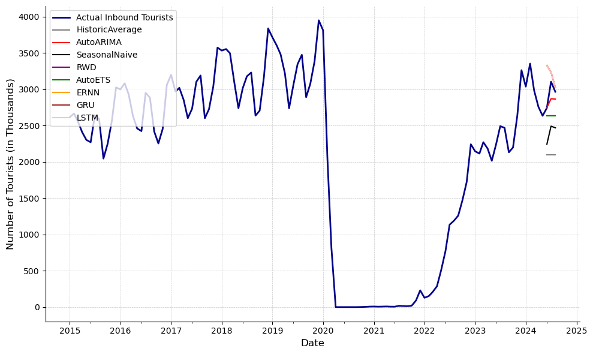

Figure 8: Comparison of forecasted and actual inbound tourists

## 7 Conclusion

Given the growing importance of improving accuracy in forecasting tourist demand for the travel industry and policymakers, and the increasing interest in Neural Networks, this study demonstrates that RNN is effective for short-term forecasting of inbound tourist demand in Thailand. RNN outperforms benchmarks such as Historic Average, Seasonal Naïve, Random Walk with Drift and AutoETS, particularly in terms of SMAPE and MASE. The short length of the time series and its temporal patterns emphasize the importance of careful data preprocessing and hyperparameter optimization, which require specialized expertise and higher computational resources. Among the different RNN cell types, ERNN emerges as the most suitable option due to its simpler architecture, fewer parameters, and improved statistical properties, providing enhanced interpretability despite only marginal differences in performance across the evaluated metrics. However, traditional models such as AutoARIMA continue to demonstrate that simpler approaches often remain competitive when forecasting with limited observations and shorter horizons, similarly to the findings of Claveria et al. (2014). Nonetheless, the study’s conclusions are constrained by its reliance on a single dataset, which limits the generalizability of the results. Future research should validate these findings by applying the methodology to additional datasets and assessing its performance across various contexts. Furthermore, future work should focus on refining data preprocessing techniques, experimenting with alternative ways for modelling trend and seasonality and optimizing hyperparameters, including testing other learning algorithms such as COCOB (Orabona & Tommasi, 2017), as it is believed that RNN performance can be improved. A key limitation of RNN in this context is their inability to generate prediction intervals, which are crucial for assessing the uncertainty of forecasts. Future research should explore methods for generating prediction intervals to enhance the reliability of forecasts, which is particularly useful for budget allocation and strategic planning. Finally, expanding the analysis to multivariate forecasting by incorporating external variables alongside the target series could be explored to determine if predictive accuracy improves, especially when leveraging more advanced modeling techniques.

## 8 References

Abadi, M., Agarwal, A., Barham, P., Brevdo, E., Chen, Z., Citro, C., Corrado, G. S., Davis, A., Dean, J., Devin, M., Ghemawat, S., Goodfellow, I., Harp, A., Irving, G., Isard, M., Jozefowicz, R., Jia, Y., Kaiser, L., Kudlur, M., & Zheng, X. (2015). *TensorFlow: Large-scale machine learning on heterogeneous systems*. https://www.tensorflow.org/.

Athanasopoulos, G., & Silva, A. de. (2012). Multivariate exponential smoothing for forecasting tourist arrivals. *Journal of Travel Research*, *51*(5), 640–652. https://doi.org/10.1177/0047287511434115

Bandara, K., Bergmeir, C., & Smyl, S. (2020). Forecasting across time series databases using recurrent neural networks on groups of similar series: A clustering approach. *Expert Systems with Applications*, *140*, 112896.

Bank of Thailand. (n.d.). *Thailand’s economic and financial statistics*. https://app.bot.or.th/BTWS_STAT/statistics/ReportPage.aspx?reportID=875&language=eng.

Bontempi, G. (2008). Long term time series prediction with multi-input multi-output local learning. *Proceedings of the 2nd European Symposium on Time Series Prediction (TSP), ESTSP08*, 145–154.

Bontempi, G., & Taieb, S. B. (2011). Conditionally dependent strategies for multiple-step-ahead prediction in local learning. *International Journal of Forecasting*. https://doi.org/10.1016/j.ijforecast.2010.09.004

Chollet, F. (2015). *Keras*. https://keras.io.

Claveria, O., Monte, E., & Torra, S. (2014). Forecasting tourism demand to catalonia: Neural networks vs. Time series models. *Economic Modelling*, *36*, 220–228. https://doi.org/10.1016/j.econmod.2013.09.024

Claveria, O., Monte, E., & Torra, S. (2017). Data pre-processing for neural network-based forecasting: Does it really matter? *Technological and Economic Development of Economy*, *23*(5), 709–725.

Cleveland, R. B., Cleveland, W. S., McRae, J. E., & Terpenning, I. (1990). STL: A seasonal-trend decomposition procedure based on loess. *Journal of Official Statistics*, *6*(1), 3–33.

Cleveland, W. S. (1979). Robust locally weighted regression and smoothing scatterplots. *Journal of the American Statistical Association*, *74*(368), 829–836.

Duchi, J., Hazan, E., & Singer, Y. (2011). Adaptive subgradient methods for online learning and stochastic optimization. *Journal of Machine Learning Research*, *12*, 2121–2159.

Elman, J. L. (1990). Finding structure in time. *Cognitive Science*, *14*(2), 179–211.

Fernando, C. (2017). *Bayesian-optimization: Bayesian optimization of hyperparameters*. https://github.com/fmfn/BayesianOptimization.

Fields, T., Hsieh, G., & Chenou, J. (2019). Mitigating drift in time series data with noise augmentation. *2019 International Conference on Computational Science and Computational Intelligence (CSCI)*, 227–230. https://doi.org/10.1109/CSCI49370.2019.00046

Garza, F., Mergenthaler Canseco, M., Challú, C., & Olivares, K. G. (2022). *StatsForecast: Lightning fast forecasting with statistical and econometric models*. Presented at PyCon, Salt Lake City, Utah, US. https://github.com/Nixtla/statsforecast

Glorot, X., & Bengio, Y. (2010). Understanding the difficulty of training deep feedforward neural networks. In Y. W. Teh & M. Titterington (Eds.), *Proceedings of the thirteenth international conference on artificial intelligence and statistics* (Vol. 9, pp. 249–256). PMLR. https://proceedings.mlr.press/v9/glorot10a.html

Goodfellow, I., Bengio, Y., & Courville, A. (2016). *Deep learning*. MIT Press. http://www.deeplearningbook.org

Gössling, S., Scott, D., & Hall, C. M. (2020). Pandemics, tourism and global change: A rapid assessment of COVID-19. *Journal of Sustainable Tourism*, *29*(1), 1–20. https://doi.org/10.1080/09669582.2020.1758708

Hewamalage, H., Bergmeir, C., & Bandara, K. (2021). Recurrent neural networks for time series forecasting: Current status and future directions. *International Journal of Forecasting*, *37*(1), 388–427. https://doi.org/10.1016/j.ijforecast.2020.06.008

Hochreiter, S., & Schmidhuber, J. (1997). Long short-term memory. *Neural Computation*, *9*(8), 1735–1780.

Hyndman, R. J., & Athanasopoulos, G. (2021). *Forecasting: Principles and practice* (3rd ed.). OTexts. https://OTexts.com/fpp3

Hyndman, R. J., & Koehler, A. B. (2006). Another look at measures of forecast accuracy. *International Journal of Forecasting*, *22*(4), 679–688.

Intarapak, S., Supapakorn, T., & Vuthipongse, W. (2022). Classical forecasting of international tourist arrivals to thailand. *Journal of Statistical Theory and Applications*, *21*, 31–43. https://doi.org/10.1007/s44199-022-00041-5

Kingma, D. P., & Ba, J. (2015). Adam: A method for stochastic optimization. *3rd International Conference on Learning Representations (ICLR)*. https://arxiv.org/abs/1412.6980

Kline, D. M. (2004). Methods for multi-step time series forecasting with neural networks. In G. P. Zhang (Ed.), *Neural networks in business forecasting* (pp. 226–250). Information Science Publishing.

Kosungnoen, Y., & Banditwattanawong, T. (2024). Comparative analysis of deep learning and statistical algorithms for forecasting inbound foreign tourism in thailand. *Proceedings of the 2024 8th International Conference on Information Technology (InCIT)*, 769–774. https://doi.org/10.1109/InCIT63192.2024.10810650

Lim, B., & Zohren, S. (2021). Time-series forecasting with deep learning: A survey. *Philosophical Transactions of the Royal Society A*, *379*(2194), 20200209. https://doi.org/10.1098/rsta.2020.0209

Makridakis, S. (1993). Accuracy measures: Theoretical and practical concerns. *International Journal of Forecasting*, *9*(4), 527–529. https://doi.org/10.1016/0169-2070(93)90079-3

Makridakis, S., & Hibon, M. (2000). The M3-competition: Results, conclusions and implications. *International Journal of Forecasting*, *16*(4), 451–476. https://doi.org/10.1016/S0169-2070(00)00057-1

Makridakis, S., Spiliotis, E., & Assimakopoulos, V. (2018). The M4 competition: Results, findings, conclusion and way forward. *International Journal of Forecasting*, *34*(4), 802–808. https://doi.org/10.1016/j.ijforecast.2018.06.001

Mehdipour Ghazi, M., Gedeon, T., Wong, K., & Lee, M. (2019). On the initialization of long short-term memory networks. In T. Gedeon, K. Wong, & M. Lee (Eds.), *Neural information processing. ICONIP 2019* (Vol. 11953, pp. 276–284). Springer, Cham. https://doi.org/10.1007/978-3-030-36708-4_23

Nelson, M., Hill, T., Remus, W., & O’Connor, M. (1999). Time series forecasting using neural networks: Should the data be deseasonalized first? *Journal of Forecasting*, *18*(5), 359–367.

Nixtla. (n.d.). *Loss functions — utilsforecast*. https://nixtlaverse.nixtla.io/utilsforecast/losses.html.

Nixtla. (2023). *Utilsforecast: Forecasting utilities [computer software]*. GitHub. https://github.com/Nixtla/utilsforecast

Orabona, F., & Tommasi, T. (2017). Training deep networks without learning rates through coin betting. *Proceedings of the 31st International Conference on Neural Information Processing Systems (NIPS’17)*, 2157–2167.

Pascanu, R., Mikolov, T., & Bengio, Y. (2013). On the difficulty of training recurrent neural networks. *Proceedings of the 30th International Conference on Machine Learning (ICML’13)*, *28*, 1310–1318.

Perktold, J. (2024). *Statsmodels/statsmodels: Release 0.14.2*. Zenodo. https://doi.org/10.5281/zenodo.10984387

Sharda, R., & Patil, R. B. (1992). Connectionist approach to time series prediction: An empirical test. *Journal of Intelligent Manufacturing*, *3*(5), 317–323.

Smyl, S. (2020). A hybrid method of exponential smoothing and recurrent neural networks for time series forecasting. *International Journal of Forecasting*, *36*(1), 75–85. https://doi.org/10.1016/j.ijforecast.2019.03.017

Snoek, J., Larochelle, H., & Adams, R. P. (2012). Practical bayesian optimization of machine learning algorithms. In F. Pereira, C. J. C. Burges, L. Bottou, & K. Q. Weinberger (Eds.), *Advances in neural information processing systems 25* (pp. 2951–2959). Curran Associates, Inc.

Song, H., Witt, S. F., & Li, G. (2003). Modelling and forecasting the demand for thai tourism. *Tourism Economics*, *9*(4), 363–387. https://doi.org/10.5367/000000003322663132

Suthiwartnarueput, S. (2024). *The thai economy – the current state and the way forward*. Speech at the Japanese Chamber of Commerce (JCC) Dinner Talk, Siam, 25 March 2024. https://www.bis.org/review/r240416i.pdf

Taieb, S. B., Bontempi, G., Atiya, A., & Sorjamaa, A. (2012). A review and comparison of strategies for multi-step ahead time series forecasting based on the NN5 forecasting competition. *Expert Systems with Applications*, *39*(8), 7067–7083. https://doi.org/10.1016/j.eswa.2012.01.039

Tang, Z., Almeida, C. de, & Fishwick, P. A. (1991). Time series forecasting using neural networks vs. Box-jenkins methodology. *Simulation*, *57*(5), 303–310. https://doi.org/10.1177/003754979105700507

UNWTO. (2020). *Impact assessment of the COVID-19 outbreak on international tourism*. https://www.unwto.org/impact-assessment-of-the-covid-19-outbreak-on-international-tourism.

Wen, R., Torkkola, K., Narayanaswamy, B., & Madeka, D. (2017). A multi-horizon quantile recurrent forecaster. *31st Conference on Neural Information Processing Systems (NIPS 2017), Time Series Workshop*.

Zhang, G. P., & Kline, D. M. (2007). Quarterly time-series forecasting with neural networks. *IEEE Transactions on Neural Networks*, *18*(6), 1800–1814. https://doi.org/10.1109/TNN.2007.896891

Zhang, G. P., & Qi, M. (2005). Neural network forecasting for seasonal and trend time series. *European Journal of Operational Research*, *160*(2), 501–514. https://doi.org/10.1016/j.ejor.2003.08.037